# Statistics Project - Assignment 1

Gur Keinan, 213635899

Naomi Derel, 325324994

```python
import numpy as np
import pandas as pd
```

## Part 1 - Data File

We picked the "Cardiovascular Diseases Risk Prediction Dataset".

```python
data = pd.read_csv('CVD_cleaned.csv')
len(data)
```

```
308854
```

### Short description

The data consists of 19 variables, which describe the health and lifestyle of a person. These factors can be contributed to being at risk with any form of Cardiovascular Diseases.

The data was collected in a survey by The Behavioral Risk Factor Surveillance System in the USA. It contains 308854 rows and 19 columns.

### Link to the source

https://www.kaggle.com/datasets/alphiree/cardiovascular-diseases-risk-prediction-dataset?resource=download

### Data transformations

Tranformation 1 - Changing the diabities feature to be categorical with 3 options.

First we will change variable name in the diabities feature from 'No, pre-diabetes or borderline diabetes' to 'at risk', in order to define it as a more general category. In addition, we will remove records with the value 'Yes, but female told only during pregnancy' from the feature, because it could be caused by Gestational diabetes - which is a temporary condition that occurs during pregnancy. We don't want to include this in our analysis, because it might not a permanent condition, and we don't want to change it to one of the other values to avoid unintentional changes to the meaning of the data.

```python
data.loc[data["Diabetes"] == 'No, pre-diabetes or borderline diabetes', "Diabetes"] = 'at risk'
data = data[data["Diabetes"] != 'Yes, but female told only during pregnancy']
```

Transformation 2 - Adding a numerical age category variable.

We noticed the age category has categories by age, each category has a range of age in a string. We decided to add a numerical age variable, in order to create an order relation between the categories. We describe the age category by the lowest age in the range.

```python
data["Numerical_Age_Category"] = data["Age_Category"].apply(lambda x: int(x[:2]))
data["Numerical_Age_Category"]
```

```
0         70
1         70
2         60
3         75
4         80
          ..
308848    55
308849    25
308850    65
308852    65
308853    45
Name: Numerical_Age_Category, Length: 306208, dtype: int64
```

### Feature description

```python
# Number of records in the data after transformation
print("Number of records in the data after transformation: ", len(data))
```

```
Number of records in the data after transformation:  306208
```

```python
# Technical description of columns in the data:
data.info()
```

```
<class 'pandas.core.frame.DataFrame'>
Int64Index: 306208 entries, 0 to 308853
Data columns (total 20 columns):
 #   Column                        Non-Null Count   Dtype
---  ------                        --------------   -----
 0   General_Health                306208 non-null  object
 1   Checkup                       306208 non-null  object
 2   Exercise                      306208 non-null  object
 3   Heart_Disease                 306208 non-null  object
 4   Skin_Cancer                   306208 non-null  object
 5   Other_Cancer                  306208 non-null  object
 6   Depression                    306208 non-null  object
 7   Diabetes                      306208 non-null  object
 8   Arthritis                     306208 non-null  object
 9   Sex                           306208 non-null  object
 10  Age_Category                  306208 non-null  object
 11  Height_(cm)                   306208 non-null  float64
 12  Weight_(kg)                   306208 non-null  float64
 13  BMI                           306208 non-null  float64
 14  Smoking_History               306208 non-null  object
 15  Alcohol_Consumption           306208 non-null  float64
 16  Fruit_Consumption             306208 non-null  float64
 17  Green_Vegetables_Consumption  306208 non-null  float64
 18  FriedPotato_Consumption       306208 non-null  float64
 19  Numerical_Age_Category        306208 non-null  int64
dtypes: float64(7), int64(1), object(12)
memory usage: 49.1+ MB
```

#### Detailed Description of Columns:

General_Health:

- Type: categorical
- Unique values: ['Poor', 'Fair', 'Good', 'Very Good', 'Excellent']
- Missing values: 0
- Description: General health status as described by the individual.

Checkup:

- Type: binary
- Missing values: 0
- Description: Whether the individual exercised in the past month other than their regular job.

Heart_Disease:

- Type: binary
- Missing values: 0
- Description: Indicates whether the individual has been diagnosed with heart disease.

Skin_Cancer:

- Type: binary
- Missing values: 0
- Description: Indicates whether the individual has been diagnosed with skin cancer.

Other_Cancer:

- Type: binary
- Missing values: 0
- Description: Indicates whether the individual has been diagnosed with types of cancer other than skin cancer.

Depression:

- Type: binary
- Missing values: 0
- Description: Indicates whether the individual has been diagnosed with depression.

Diabetes:

- Type: categorical
- Unique values: ['No', 'at risk', 'Yes']
- Missing values: 0
- Description: Indicates whether the individual has been diagnosed with diabetes or is at risk of diabetes.

Arthritis:

- Type: binary
- Missing values: 0
- Description: Indicates whether the individual has been diagnosed with arthritis.

Sex:

- Type: categorical
- Unique values: ['Male', 'Female']
- Missing values: 0
- Description: Sex of the individual.

Age_Category:

- Type: categorical
- Unique values: ['18-24', '25-29', '30-34', '35-39', '40-44', '45-49', '50-54', '55-59', '60-64', '65-69', '70-74', '75-79', '80+']
- Missing values: 0
- Description: Age category of the individual.

Height_(cm):

- Type: numerical (float)
- Missing values: 0
- Description: Height of the individual in centimeters.

Weight_(kg):

- Type: numerical (float)
- Missing values: 0
- Description: Weight of the individual in kilograms.

BMI:

- Type: numerical (float)
- Missing values: 0
- Description: Body Mass Index (BMI) of the individual, calculated from height and weight.

Smoking_History:

- Type: binary
- Missing values: 0
- Description: Smoking history of the individual.

##### Note: We saw in the documentation that the following columns, regarding consumption, are measured in units per month. From our knowledge of the domain, we assume that these variables are numerical and not categorical - for example, it is possible to consume half a glass of alcohol per month.

Alcohol_Consumption:

- Type: numerical (float)
- Missing values: 0
- Description: Amount of alcohol consumption by the individual per month.

Fruit_Consumption:

- Type: numerical (float)
- Missing values: 0
- Description: Frequency of fruit consumption by the individual per month.

Green_Vegetables_Consumption:

- Type: numerical (float)
- Missing values: 0
- Description: Frequency of green vegetables consumption by the individual per month.

FriedPotato_Consumption:

- Type: numerical (float)
- Missing values: 0
- Description: Frequency of fried potato consumption by the individual per month.

Numerical_Age_Category:

- Type: categorical
- Unique values: ['18', '25', '30', '35', '40', '45', '50', '55', '60', '65', '70', '75', '80']
- Missing values: 0
- Description: Numerical indication of age category of the individual.

## Part 2 - Data Visualization

```python
# There are no missing values in the data:
data[data.isnull().any(axis=1)]
```

|  | General_Health | Checkup | Exercise | Heart_Disease | Skin_Cancer | Other_Cancer | Depression | Diabetes | Arthritis | Sex | Age_Category | Height_(cm) | Weight_(kg) | BMI | Smoking_History | Alcohol_Consumption | Fruit_Consumption | Green_Vegetables_Consumption | FriedPotato_Consumption | Numerical_Age_Category |
| --- | --- | --- | --- | --- | --- | --- | --- | --- | --- | --- | --- | --- | --- | --- | --- | --- | --- | --- | --- | --- |

We noticed that the alohol consumtion graph was unbalances since there were a lot of people who reported 0. Based on the example we saw in the tutorial, we are presenting an additional boxplot to show the outliers where we dont consider the people who reported 0.

```
Height_(cm)
mean: 170.683
variance: 113.511
median:  170.0
min:  91.0
max:  241.0
total number of outliers:  1043
number of outliers above:  600
number of outliers below:  443
```

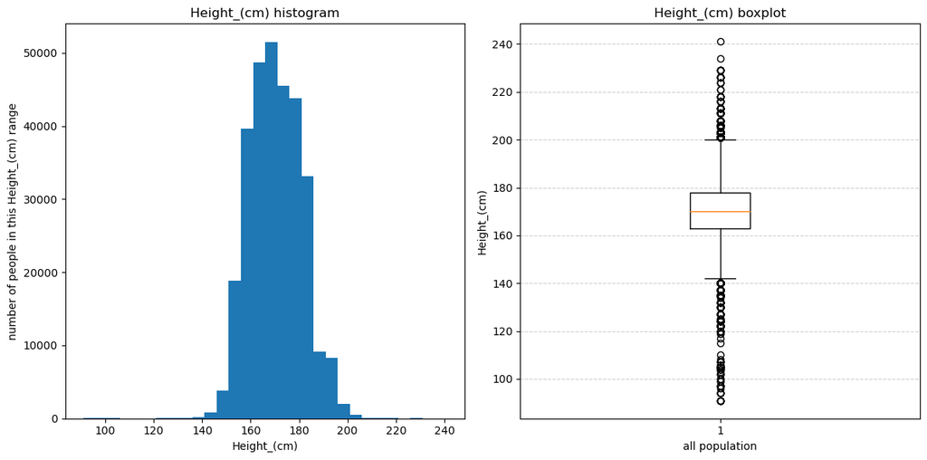

```
Weight_(kg)
mean: 83.632
variance: 455.982
median:  81.65
min:  24.95
max:  293.02
total number of outliers:  7289
number of outliers above:  7284
number of outliers below:  5
```

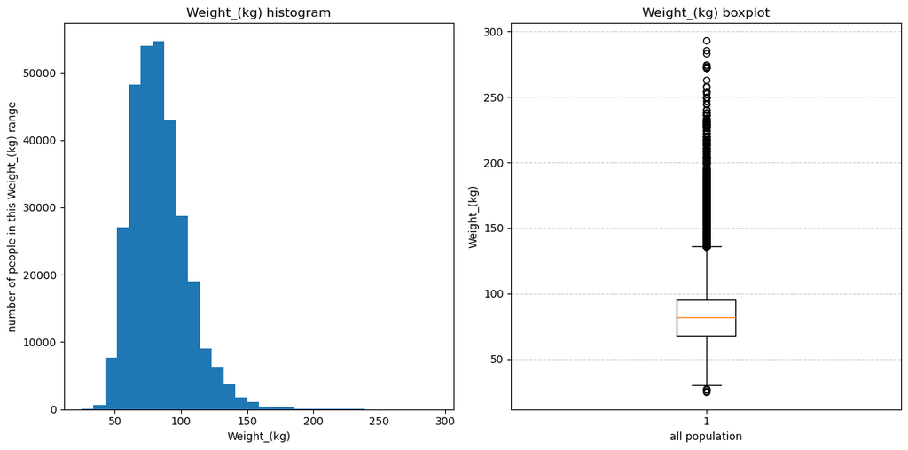

```
BMI
mean: 28.617
variance: 42.473
median:  27.44
min:  12.02
max:  99.33
total number of outliers:  9629
number of outliers above:  9608
number of outliers below:  21
```

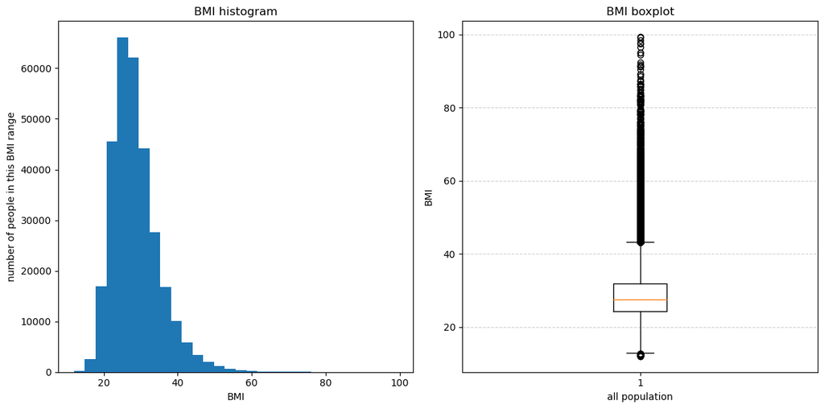

```
Alcohol_Consumption
mean: 5.107
variance: 67.402
median:  1.0
min:  0.0
max:  30.0

outliers where 0 is included:
total number of outliers:  35959
number of outliers above:  35959
number of outliers below:  0

outliers where 0 is excluded:
total number of outliers:  0
number of outliers above:  0
number of outliers below:  0
```

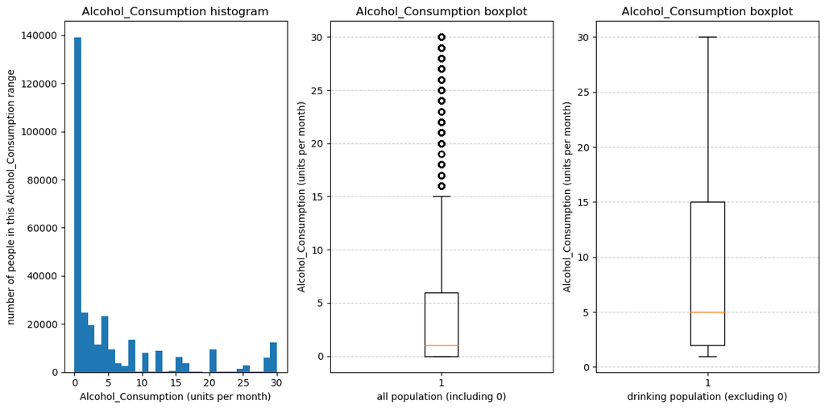

```
Fruit_Consumption
mean: 29.816
variance: 618.530
median:  30.0
min:  0.0
max:  120.0
total number of outliers:  67552
number of outliers above:  67552
number of outliers below:  0
```

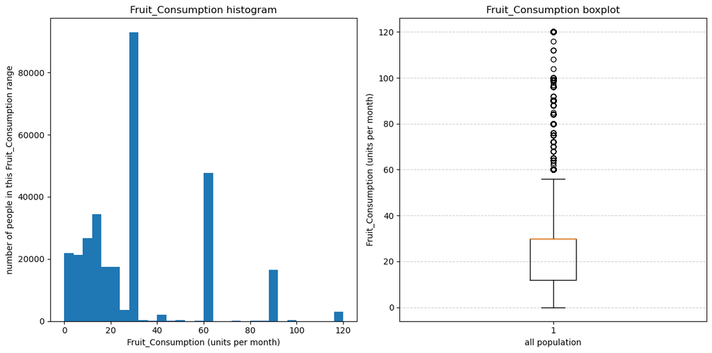

```
Green_Vegetables_Consumption
mean: 15.100
variance: 222.333
median:  12.0
min:  0.0
max:  128.0
total number of outliers:  11734
number of outliers above:  11734
number of outliers below:  0
```

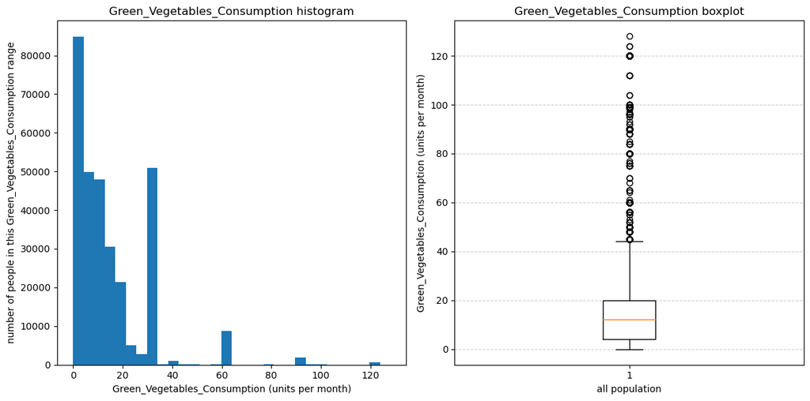

```
FriedPotato_Consumption
mean: 6.296
variance: 73.527
median:  4.0
min:  0.0
max:  128.0
total number of outliers:  19281
number of outliers above:  19281
number of outliers below:  0
```

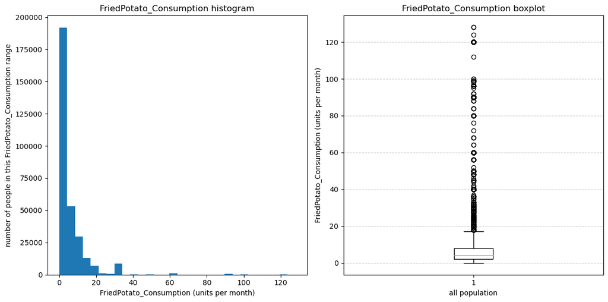

```
General_Health
number of unique values:  5
most frequent value:  Very Good
```

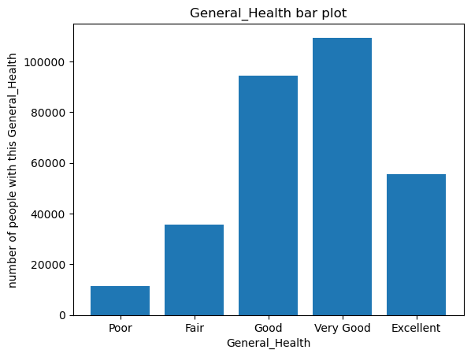

```
Checkup
number of unique values:  5
most frequent value:  Within the past year
```

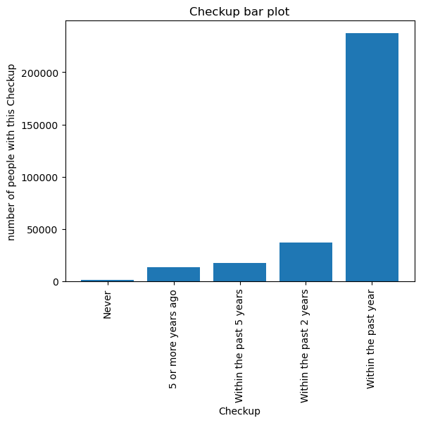

```
Exercise
number of unique values:  2
most frequent value:  Yes
```

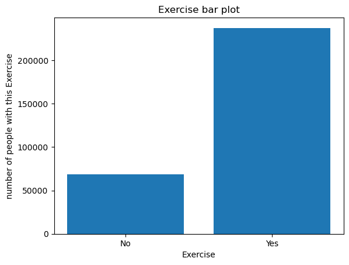

```
Heart_Disease
number of unique values:  2
most frequent value:  No
```

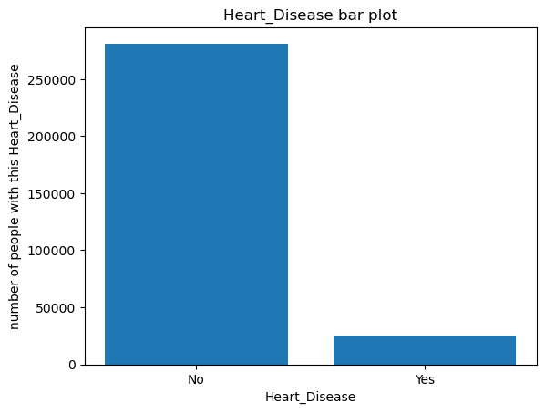

```
Skin_Cancer
number of unique values:  2
most frequent value:  No
```

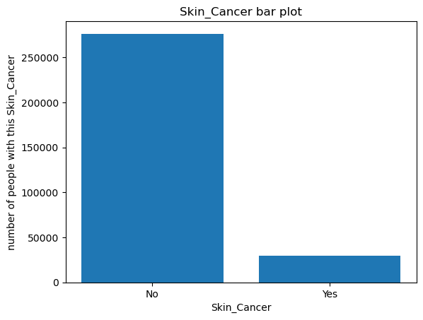

```
Other_Cancer
number of unique values:  2
most frequent value:  No
```

[8 more figures not shown]

```python
import matplotlib.pyplot as plt

numerical_variables_list = []
categorical_variables_list = []

for variable_name in data.columns:
    if data[variable_name].dtype == "object" or variable_name == "Numerical_Age_Category":
        categorical_variables_list.append(variable_name)
    else:
        numerical_variables_list.append(variable_name)

# for every numerical variable make histogram and report of mean, variance, median, min, max
for variable_name in numerical_variables_list:
    if variable_name != "Alcohol_Consumption":
        print(variable_name)
        print(f"mean: {data[variable_name].mean():.3f}")
        print(f"variance: {data[variable_name].var():.3f}")
        print("median: ", data[variable_name].median())
        print("min: ", data[variable_name].min())
        print("max: ", data[variable_name].max())

        # Report on outliers - values that are outside the whiskers of the boxplot
        q1 = data[variable_name].quantile(0.25)
        q3 = data[variable_name].quantile(0.75)
        iqr = q3 - q1
        lower_bound = q1 - (1.5 * iqr)
        upper_bound = q3 + (1.5 * iqr)
        print("total number of outliers: ", len(data[(data[variable_name] < lower_bound) | (data[variable_name] > upper_bound)]))
        print("number of outliers above: ", len(data[data[variable_name] > upper_bound]))
        print("number of outliers below: ", len(data[data[variable_name] < lower_bound]))


        # Create a figure with two subplots side by side
        fig, axes = plt.subplots(nrows=1, ncols=2, figsize=(12, 6))

        # Plot histogram in the first subplot
        axes[0].hist(data[variable_name], bins=30)

        if variable_name in ["Fruit_Consumption", "Green_Vegetables_Consumption", "FriedPotato_Consumption"]:
            axes[0].set_xlabel(variable_name + " (units per month)")
            axes[1].set_ylabel(variable_name + " (units per month)")
        else:
            axes[0].set_xlabel(variable_name)
            axes[1].set_ylabel(variable_name)


        axes[0].set_ylabel("number of people in this " + variable_name + " range")
        axes[0].set_title(variable_name + " histogram")

        # Plot boxplot in the second subplot
        axes[1].boxplot(data[variable_name])

        axes[1].yaxis.grid(True, alpha=0.6, linestyle='--')
        axes[1].set_title(variable_name + " boxplot")
        axes[1].set_xlabel("all population")

        # Adjust layout to prevent overlap
        plt.tight_layout()

        # Display the plots
        plt.show()
        print()
    else:
        print(variable_name)
        print(f"mean: {data[variable_name].mean():.3f}")
        print(f"variance: {data[variable_name].var():.3f}")
        print("median: ", data[variable_name].median())
        print("min: ", data[variable_name].min())
        print("max: ", data[variable_name].max())

        # Report on outliers - values that are outside the whiskers of the boxplot
        print()
        print("outliers where 0 is included:")
        q1 = data[variable_name].quantile(0.25)
        q3 = data[variable_name].quantile(0.75)
        iqr = q3 - q1
        lower_bound = q1 - (1.5 * iqr)
        upper_bound = q3 + (1.5 * iqr)
        print("total number of outliers: ", len(data[(data[variable_name] < lower_bound) | (data[variable_name] > upper_bound)]))
        print("number of outliers above: ", len(data[data[variable_name] > upper_bound]))
        print("number of outliers below: ", len(data[data[variable_name] < lower_bound]))

        print()
        print("outliers where 0 is excluded:")
        data_without_0 = data[data[variable_name] != 0]
        q1 = data_without_0[variable_name].quantile(0.25)
        q3 = data_without_0[variable_name].quantile(0.75)
        iqr = q3 - q1
        lower_bound = q1 - (1.5 * iqr)
        upper_bound = q3 + (1.5 * iqr)
        print("total number of outliers: ", len(data_without_0[(data_without_0[variable_name] < lower_bound) | (data_without_0[variable_name] > upper_bound)]))
        print("number of outliers above: ", len(data_without_0[data_without_0[variable_name] > upper_bound]))
        print("number of outliers below: ", len(data_without_0[data_without_0[variable_name] < lower_bound]))


        # Create a figure with two subplots side by side
        fig, axes = plt.subplots(nrows=1, ncols=3, figsize=(12, 6))

        # Plot histogram in the first subplot
        axes[0].hist(data[variable_name], bins=30)
        axes[0].set_xlabel(variable_name + " (units per month)")
        axes[0].set_ylabel("number of people in this " + variable_name + " range")
        axes[0].set_title(variable_name + " histogram")

        # Plot boxplot in the second subplot
        axes[1].boxplot(data[variable_name])
        axes[1].set_ylabel(variable_name + " (units per month)")
        axes[1].yaxis.grid(True, alpha=0.6, linestyle='--')
        axes[1].set_title(variable_name + " boxplot")
        axes[1].set_xlabel("all population (including 0)")

        # Plot boxplot in the third subplot
        axes[2].boxplot(data_without_0[variable_name])
        axes[2].set_ylabel(variable_name + " (units per month)")
        axes[2].yaxis.grid(True, alpha=0.6, linestyle='--')
        axes[2].set_title(variable_name + " boxplot")
        axes[2].set_xlabel("drinking population (excluding 0)")


        # Adjust layout to prevent overlap
        plt.tight_layout()

        # Display the plots
        plt.show()
        print()


# for every categorial and binary variable make bar plot and report of number of unique values and most frequent value
for variable_name in categorical_variables_list:
    categories = data[variable_name].unique()
    value_counts_sorted = data[variable_name].value_counts().reindex(categories)

    if variable_name == "Numerical_Age_Category":
        categories = [str(i) for i in sorted(data[variable_name].unique())]
        value_counts_sorted = data[variable_name].value_counts().reindex(sorted(data[variable_name].unique()))
    elif variable_name == "Age_Category":
        categories = [str(i) for i in sorted(data[variable_name].unique(), key=lambda x: int(x[:2]))]
        value_counts_sorted = data[variable_name].value_counts().reindex(categories)
    elif variable_name == "Checkup":
        categories = ['Never', '5 or more years ago', 'Within the past 5 years', 'Within the past 2 years', 'Within the past year']
        value_counts_sorted = data[variable_name].value_counts().reindex(categories)
    elif variable_name == "General_Health":
        categories = ['Poor', 'Fair', 'Good', 'Very Good', 'Excellent']
        value_counts_sorted = data[variable_name].value_counts().reindex(categories)

    print(variable_name)
    print("number of unique values: ", len(data[variable_name].unique()))
    print("most frequent value: ", data[variable_name].value_counts().idxmax())

    # This ensures that value counts are in the same order as 'categories'


    plt.bar(categories, value_counts_sorted)

    if variable_name == "Checkup" or variable_name == "Age_Category":
        plt.xticks(rotation=90)
    plt.xlabel(variable_name)
    plt.ylabel("number of people with this " + variable_name)
    plt.title(variable_name + " bar plot")
    plt.show()
    print()
```

## Part 3 - Research Questions

Note: as we explained before, we view consumption variables as numerical.

A.

- Does an increase in fried potato consumption increases BMI?
- Does an increase in green vegetables' consumption decreases BMI?

B.

- Does an increase in Weight increases the probability of heart diseases being true?
- Does an increase in BMI increases the probability of arthritis being true?

C.

- Does the value of alcohol consumption differ between populations with and without depression?
- Does the value of green vegetables' consumption differ between populations which do and don't exercise?